# Pinwheel Empire Analytics

### Player Pairs Analysis

Simons & Nance Jr. have become key guys off the bench to spark the team.

A Simons, Powell, McCollum, Nance 2nd rotation could turnout to be pretty effective for the Blazers given the 2 way ability of this squad to score and defend. Nance gives you extra possessions given his defensive presence (more so than RoCo at this point in the season)

Little will have to continue to improve his defensive game when paired with starters like Dame & Nurkic given their defensive deficiencies otherwise Nance would get the nod down the stretch.

Blazer Pairings Efficiency Rating

| group_name | min | poss | e_off_rating | e_def_rating | e_net_rating | pace_per40 |
| --- | --- | --- | --- | --- | --- | --- |
| R. Covington - L. Nance Jr. | 52 | 109 | 122.9 | 103.8 | 19.1 | 83.75 |
| C. McCollum - T. Snell | 78 | 153 | 122.7 | 107.5 | 15.2 | 77.94 |
| J. Nurkic - A. Simons | 119 | 253 | 108.9 | 94.1 | 14.8 | 83.45 |
| N. Powell - A. Simons | 105 | 222 | 116.7 | 103.1 | 13.6 | 84.49 |
| C. Zeller - L. Nance Jr. | 130 | 269 | 115.0 | 106.2 | 8.8 | 83.91 |
| D. Lillard - L. Nance Jr. | 168 | 355 | 115.8 | 108.0 | 7.7 | 85.29 |
| D. Lillard - J. Nurkic | 358 | 763 | 110.2 | 102.5 | 7.6 | 84.85 |
| C. McCollum - L. Nance Jr. | 223 | 455 | 115.3 | 108.6 | 6.7 | 82.15 |
| D. Lillard - N. Powell | 386 | 812 | 114.9 | 109.3 | 5.7 | 83.88 |
| L. Nance Jr. - A. Simons | 235 | 481 | 113.0 | 107.3 | 5.7 | 82.91 |
| J. Nurkic - N. Little | 90 | 194 | 105.9 | 100.6 | 5.4 | 86.38 |
| D. Lillard - A. Simons | 186 | 394 | 109.4 | 104.2 | 5.2 | 84.28 |
| N. Powell - L. Nance Jr. | 95 | 199 | 119.6 | 114.5 | 5.1 | 85.09 |
| R. Covington - N. Powell | 344 | 719 | 113.8 | 108.8 | 5.0 | 83.62 |
| J. Nurkic - N. Powell | 316 | 669 | 112.1 | 107.9 | 4.1 | 84.01 |

Note:  
>100 possessions; Top 15

## Specialty Narratives

### CJ an All-Star?

There will be 24 all stars but we are showing top 40 players in the league to highlight potential snubs. The data is organized by the highest VORP (Value over replacement player) and then PER in-case of VORP ties.

CJ currently is not in the top VORP for giving him All-Star consideration.

Positive Surprises in the season so far:  
-John Collins  
-Miles Bridges  
-Montrezl Harrell  
-Richaun Holmes  
-Dejounte Murray

RK

vorp

Name

pos

tm

g

mp

mp/g

per

ows

dws

ws

ws_48

1

2.0

Nikola Jokić

C

[figure not shown]

DEN

14

454

32.4

35.3

2.3

0.9

3.2

0.342

2

1.7

Giannis Antetokounmpo

PF

[figure not shown]

MIL

17

555

32.6

30.2

1.9

1.1

3.0

0.263

3

1.5

Jimmy Butler

SF

[figure not shown]

MIA

14

472

33.7

30.6

2.6

0.8

3.4

0.341

4

1.5

Stephen Curry

PG

[figure not shown]

GSW

16

542

33.9

27.7

2.2

1.1

3.3

0.290

5

1.4

Kevin Durant

PF

[figure not shown]

BRK

17

594

34.9

27.6

2.3

0.8

3.1

0.250

6

1.2

Montrezl Harrell

C

[figure not shown]

WAS

17

482

28.4

28.6

2.5

0.7

3.3

0.325

7

1.0

Karl-Anthony Towns

C

[figure not shown]

MIN

17

592

34.8

23.4

1.7

0.9

2.6

0.210

8

1.0

Paul George

SF

[figure not shown]

LAC

17

594

34.9

21.1

0.3

1.2

1.5

0.124

9

1.0

LaMelo Ball

PG

[figure not shown]

CHO

19

631

33.2

20.8

0.9

0.7

1.7

0.127

10

0.9

Rudy Gobert

C

[figure not shown]

UTA

17

525

30.9

26.5

2.0

1.3

3.3

0.298

11

0.9

DeMar DeRozan

SF

[figure not shown]

CHI

18

631

35.1

24.2

2.0

0.7

2.7

0.206

12

0.9

James Harden

PG

[figure not shown]

BRK

18

629

34.9

21.4

1.3

1.0

2.2

0.172

13

0.8

Anthony Davis

C

[figure not shown]

LAL

18

631

35.1

26.1

1.7

0.9

2.6

0.196

14

0.8

Ja Morant

PG

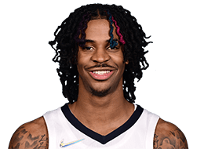

MEM

17

576

33.9

24.8

1.6

0.1

1.7

0.143

15

0.8

Trae Young

PG

[figure not shown]

ATL

18

613

34.1

23.2

1.8

0.1

1.9

0.151

16

0.8

Chris Paul

PG

[figure not shown]

PHO

17

539

31.7

22.1

1.7

0.9

2.6

0.231

17

0.8

John Collins

PF

[figure not shown]

ATL

18

578

32.1

21.9

2.0

0.5

2.5

0.204

18

0.8

Zach LaVine

SG

[figure not shown]

CHI

18

628

34.9

21.6

1.3

0.6

1.9

0.147

19

0.8

Al Horford

C

[figure not shown]

BOS

15

441

29.4

21.1

1.0

0.9

1.9

0.206

20

0.8

Domantas Sabonis

C

[figure not shown]

IND

19

645

33.9

21.1

1.5

0.9

2.4

0.182

21

0.7

Jonas Valančiūnas

C

[figure not shown]

NOP

19

618

32.5

22.7

1.7

0.5

2.2

0.169

22

0.7

Donovan Mitchell

SG

[figure not shown]

UTA

16

515

32.2

21.7

1.1

0.7

1.7

0.163

23

0.7

Malcolm Brogdon

PG

[figure not shown]

IND

14

479

34.2

20.9

1.2

0.5

1.6

0.165

24

0.7

Myles Turner

C

[figure not shown]

IND

19

537

28.3

19.9

1.0

1.0

2.0

0.181

25

0.7

Harrison Barnes

PF

[figure not shown]

SAC

18

636

35.3

19.2

1.8

0.4

2.2

0.163

26

0.7

Fred VanVleet

PG

[figure not shown]

TOR

17

648

38.1

17.7

1.1

0.4

1.6

0.116

27

0.7

Draymond Green

PF

[figure not shown]

GSW

16

477

29.8

15.9

0.8

1.0

1.9

0.187

28

0.6

Luka Dončić

PG

[figure not shown]

DAL

13

452

34.8

21.7

0.2

0.6

0.8

0.081

29

0.6

Jarrett Allen

C

[figure not shown]

CLE

15

490

32.7

21.3

1.2

0.8

2.0

0.200

30

0.6

Mike Conley

PG

[figure not shown]

UTA

15

426

28.4

19.3

1.5

0.4

1.9

0.212

31

0.6

Dejounte Murray

PG

[figure not shown]

SAS

16

554

34.6

19.2

0.3

0.8

1.2

0.100

32

0.6

Miles Bridges

PF

[figure not shown]

CHO

19

700

36.8

17.8

1.1

0.5

1.6

0.111

33

0.6

Will Barton

SG

[figure not shown]

DEN

15

498

33.2

17.5

0.7

0.6

1.3

0.128

34

0.6

Nicolas Batum

PF

[figure not shown]

LAC

14

386

27.6

15.6

0.7

0.7

1.4

0.178

35

0.5

Richaun Holmes

C

[figure not shown]

SAC

18

493

27.4

23.1

1.8

0.5

2.3

0.222

37

0.5

Robert Williams

C

[figure not shown]

BOS

14

423

30.2

21.0

1.3

0.7

2.0

0.228

38

0.5

Tyrese Maxey

PG

[figure not shown]

PHI

18

641

35.6

19.4

1.9

0.2

2.1

0.160

39

0.5

Jayson Tatum

SF

[figure not shown]

BOS

18

661

36.7

19.2

0.5

0.9

1.5

0.106

40

0.5

Derrick Rose

PG

[figure not shown]

NYK

17

390

22.9

18.9

0.6

0.3

0.9

0.116

41

0.5

Julius Randle

PF

[figure not shown]

NYK

17

603

35.5

18.0

0.6

0.6

1.2

0.099

### Norm vs. Trent Tracker

Name

pos

tm

g

mp

mp/g

ws

ws_48

vorp

ows

dws

per

tspercent

x3par

ftr

trbpercent

usgpercent

Gary Trent Jr.

SG

[figure not shown]

TOR

18

617

34.3

1.5

0.1

0.4

1.0

0.5

15.9

0.548

0.5

0.1

5.3

20.6

Norman Powell

SF

POR

15

437

29.1

1.4

0.1

0.3

1.2

0.1

18.3

0.627

0.4

0.3

4.8

21.5

### Damian Lillard Tracker

Damian Lillard Tracker

| Gm | Date | Matchup | Resut | +/- | Mins | Pts | FG% | 3P% | 3PA | FT% | FTA | AST | TREB | STL |
| --- | --- | --- | --- | --- | --- | --- | --- | --- | --- | --- | --- | --- | --- | --- |
| 17 | 2021-11-20 | POR vs. PHI | W | 9 | 37 | 39 | 0.476 | 0.385 | 13 | 1.00 | 14 | 7 | 0 | 0 |
| 16 | 2021-11-17 | POR vs. CHI | W | 15 | 40 | 22 | 0.333 | 0.333 | 9 | 1.00 | 7 | 10 | 4 | 1 |
| 15 | 2021-11-15 | POR vs. TOR | W | 7 | 40 | 24 | 0.476 | 0.500 | 6 | 1.00 | 1 | 8 | 4 | 2 |
| 13 | 2021-11-12 | POR @ HOU | W | 0 | 38 | 20 | 0.375 | 0.444 | 9 | 0.80 | 5 | 7 | 6 | 0 |
| 12 | 2021-11-10 | POR @ PHX | L | -13 | 38 | 28 | 0.522 | 0.250 | 4 | 0.75 | 4 | 7 | 7 | 0 |
| 11 | 2021-11-09 | POR @ LAC | L | -5 | 39 | 27 | 0.478 | 0.308 | 13 | 1.00 | 1 | 6 | 5 | 0 |
| 10 | 2021-11-06 | POR vs. LAL | W | 29 | 31 | 25 | 0.474 | 0.429 | 14 | 0.50 | 2 | 6 | 3 | 2 |
| 9 | 2021-11-05 | POR vs. IND | W | -4 | 38 | 4 | 0.154 | 0.000 | 6 | NA | 0 | 11 | 4 | 1 |
| 8 | 2021-11-03 | POR @ CLE | L | 5 | 40 | 26 | 0.370 | 0.250 | 12 | 0.60 | 5 | 8 | 3 | 2 |
| 7 | 2021-11-01 | POR @ PHI | L | -14 | 36 | 20 | 0.350 | 0.222 | 9 | 0.80 | 5 | 10 | 7 | 0 |

Note:  
Showing Last 10 games

### FA Performance Tracker

Free Agent Comparison (Past & New)

| Player | pos | age.x | OTm | NTm | g | mp | vorp | ws | ws_48 | ows | dws | per | tspercent | x3par | ftr | usgpercent |
| --- | --- | --- | --- | --- | --- | --- | --- | --- | --- | --- | --- | --- | --- | --- | --- | --- |
| Montrezl Harrell | C | 28 | LAL |  | 17 | 482 | 1.2 | 3.3 | 0.325 | 2.5 | 0.7 | 28.6 | 0.71 | 0.04 | 0.54 | 21.2 |
| DeMar DeRozan | SF | 32 | SAS | CHI | 18 | 631 | 0.9 | 2.7 | 0.206 | 2.0 | 0.7 | 24.2 | 0.59 | 0.13 | 0.42 | 30.8 |
| Chris Paul | PG | 36 | PHO | PHO | 17 | 539 | 0.8 | 2.6 | 0.231 | 1.7 | 0.9 | 22.1 | 0.57 | 0.28 | 0.33 | 19.7 |
| John Collins | PF | 24 | ATL | ATL | 18 | 578 | 0.8 | 2.5 | 0.204 | 2.0 | 0.5 | 21.9 | 0.64 | 0.24 | 0.28 | 18.9 |
| Jarrett Allen | C | 23 | CLE | CLE | 15 | 490 | 0.6 | 2.0 | 0.200 | 1.2 | 0.8 | 21.3 | 0.67 | 0.03 | 0.44 | 17.2 |
| Mike Conley | PG | 34 | UTA | UTA | 15 | 426 | 0.6 | 1.9 | 0.212 | 1.5 | 0.4 | 19.3 | 0.65 | 0.57 | 0.15 | 18.9 |
| Nicolas Batum | PF | 33 | LAC | LAC | 14 | 386 | 0.6 | 1.4 | 0.178 | 0.7 | 0.7 | 15.6 | 0.68 | 0.76 | 0.10 | 12.6 |
| Will Barton | SG | 31 | DEN | DEN | 15 | 498 | 0.6 | 1.3 | 0.128 | 0.7 | 0.6 | 17.5 | 0.56 | 0.43 | 0.12 | 21.9 |
| Richaun Holmes | C | 28 | SAC | SAC | 18 | 493 | 0.5 | 2.3 | 0.222 | 1.8 | 0.5 | 23.1 | 0.73 | 0.02 | 0.30 | 17.8 |
| Derrick Rose | PG | 33 | NYK | NYK | 17 | 390 | 0.5 | 0.9 | 0.116 | 0.6 | 0.3 | 18.9 | 0.54 | 0.34 | 0.09 | 23.7 |
| Alec Burks | SG | 30 | NYK | NYK | 17 | 358 | 0.4 | 1.2 | 0.160 | 0.8 | 0.4 | 16.7 | 0.60 | 0.65 | 0.27 | 18.2 |
| Lonzo Ball | PG | 24 | NOP | CHI | 18 | 627 | 0.4 | 1.1 | 0.087 | 0.3 | 0.9 | 13.0 | 0.54 | 0.61 | 0.03 | 16.9 |
| Josh Hart | PF | 26 | NOP | NOP | 15 | 446 | 0.4 | 1.1 | 0.121 | 0.9 | 0.2 | 16.2 | 0.60 | 0.28 | 0.27 | 16.1 |
| Carmelo Anthony | PF | 37 | POR | LAL | 18 | 519 | 0.4 | 1.4 | 0.134 | 1.1 | 0.4 | 16.3 | 0.63 | 0.57 | 0.19 | 19.0 |
| Isaiah Hartenstein | C | 23 | CLE | LAC | 16 | 258 | 0.4 | 1.4 | 0.253 | 0.7 | 0.7 | 22.9 | 0.66 | 0.03 | 0.36 | 18.3 |
| Mike Muscala | C | 30 | OKC | OKC | 13 | 191 | 0.4 | 0.9 | 0.223 | 0.6 | 0.3 | 22.0 | 0.64 | 0.64 | 0.37 | 21.4 |
| P.J. Tucker | PF | 36 | MIL | MIA | 17 | 484 | 0.4 | 1.5 | 0.153 | 1.0 | 0.6 | 12.4 | 0.69 | 0.51 | 0.12 | 9.9 |
| Kelly Olynyk | C | 30 | HOU | DET | 10 | 230 | 0.3 | 0.6 | 0.117 | 0.3 | 0.3 | 19.0 | 0.55 | 0.42 | 0.36 | 23.9 |
| T.J. McConnell | PG | 29 | IND | IND | 19 | 479 | 0.3 | 1.3 | 0.133 | 0.8 | 0.5 | 16.0 | 0.54 | 0.14 | 0.06 | 16.7 |
| Norman Powell | SF | 28 | POR | POR | 15 | 437 | 0.3 | 1.4 | 0.148 | 1.2 | 0.1 | 18.3 | 0.63 | 0.37 | 0.34 | 21.5 |
| Kemba Walker | PG | 31 | OKC | NYK | 16 | 394 | 0.3 | 0.8 | 0.100 | 0.5 | 0.3 | 15.6 | 0.56 | 0.52 | 0.12 | 20.9 |
| Derrick Jones Jr. | SF | 24 | POR | CHI | 14 | 252 | 0.3 | 1.2 | 0.228 | 0.8 | 0.4 | 19.4 | 0.70 | 0.23 | 0.47 | 14.3 |
| Andre Iguodala | SF | 38 | MIA | GSW | 12 | 250 | 0.3 | 0.8 | 0.160 | 0.4 | 0.5 | 12.5 | 0.49 | 0.54 | 0.14 | 9.4 |
| Nemanja Bjelica | C | 33 | MIA | GSW | 17 | 257 | 0.3 | 1.0 | 0.184 | 0.4 | 0.6 | 17.9 | 0.60 | 0.50 | 0.19 | 19.8 |
| Spencer Dinwiddie | PG | 28 | BRK | WAS | 15 | 448 | 0.3 | 1.3 | 0.136 | 0.9 | 0.4 | 16.9 | 0.54 | 0.45 | 0.20 | 23.4 |
| Bobby Portis | C | 26 | MIL | MIL | 13 | 360 | 0.2 | 1.0 | 0.140 | 0.6 | 0.5 | 18.8 | 0.57 | 0.36 | 0.14 | 22.8 |
| Danny Green | SF | 34 | PHI | PHI | 11 | 263 | 0.2 | 0.6 | 0.107 | 0.4 | 0.2 | 13.4 | 0.65 | 0.89 | 0.06 | 12.5 |
| Kyle Lowry | PG | 35 | TOR | MIA | 15 | 517 | 0.2 | 1.2 | 0.107 | 0.5 | 0.7 | 13.2 | 0.53 | 0.60 | 0.17 | 18.1 |
| Dwight Howard | C | 36 | PHI | LAL | 16 | 217 | 0.2 | 0.8 | 0.176 | 0.4 | 0.4 | 18.6 | 0.70 | 0.17 | 0.93 | 14.6 |
| Khem Birch | C | 29 | TOR | TOR | 15 | 344 | 0.2 | 1.1 | 0.152 | 0.8 | 0.2 | 17.1 | 0.55 | 0.08 | 0.41 | 12.8 |

[output cut: 117 more lines]

Note:  
If a player isn’t listed, they’ve yet to log minutes in the 2021-22 season

```
## # A tibble: 13 × 3
##     Year `Bench Pts/G` `Bench Pts %`
##    <int>         <dbl>         <dbl>
##  1  2010          29           0.297
##  2  2011          24.3         0.254
##  3  2012          32           0.329
##  4  2013          19.6         0.201
##  5  2014          24.6         0.232
##  6  2015          28.7         0.281
##  7  2016          34           0.324
##  8  2017          31.9         0.297
##  9  2018          29.4         0.277
## 10  2019          35.9         0.315
## 11  2020          28           0.245
## 12  2021          34.9         0.301
## 13  2022          34.8         0.319
```

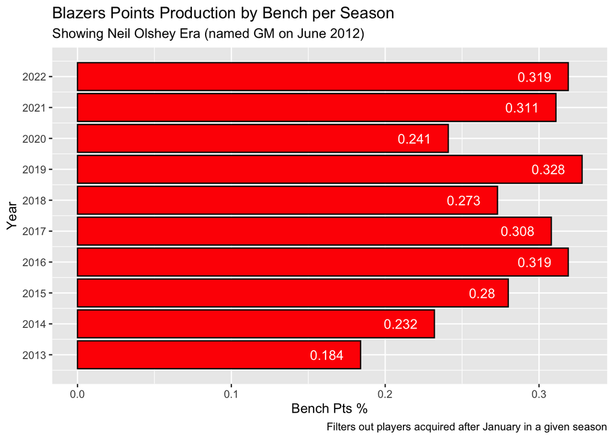